# Practical Reproducibility Instruction: Teaching Reproducibility with Technical and Non-Technical Tools

10/13/2021

## Slides Usage Notes

- Recommended to press `w` for widescreen view.
- Also recommended to press `f` for fullscreen view.
- Press `p` for Presenter Notes.
- These slides are licensed as CC-BY.

## About UVA and UVA Library

University of Virginia:

- R1 university
- 23,000 students and 12 Schools
- Only the School of Data Science has a policy for open access and open data

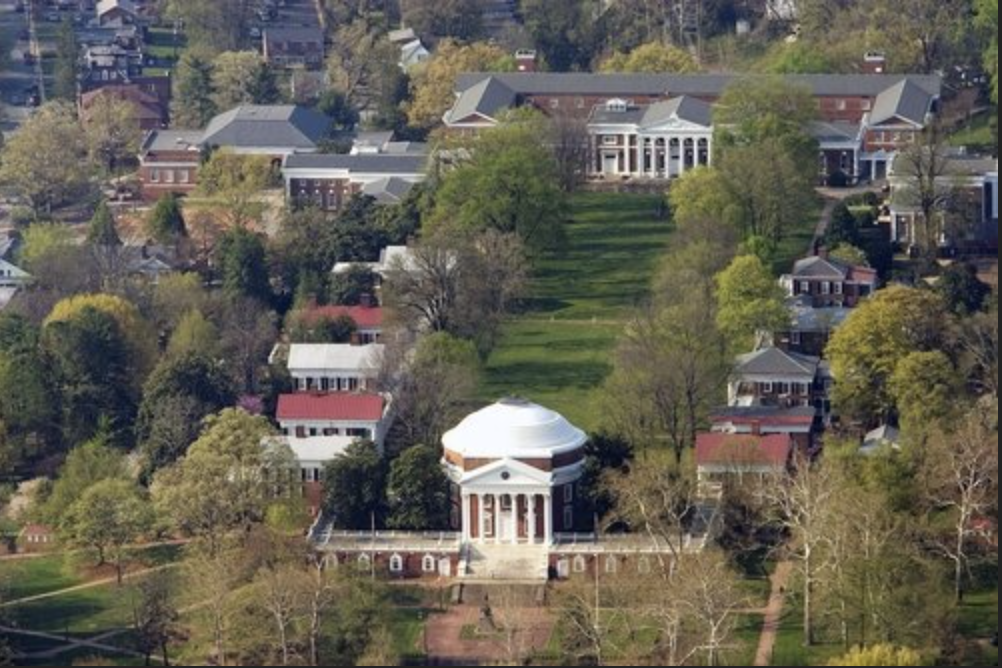

UVA Library:

- Our team members come from Scholarly Communications and Research Data Services & Social, Natural, and Engineering Sciences, which are teams from different units in the library.
- Research Data Services has a long-running workshop series.
- It is very rare for library staff to teach for-credit courses at UVA.

## What We Did

A **new workshop series**: ‘Reproducible Research for Early Graduate Students’

Included 2 **technical** and 2 **non-technical** sessions:

- Technical sessions: tools and workflows
- Non-Technical sessions: conceptual instruction on organization and data sharing

## How We Did It

- We launched it as a **standalone mini-series** as part of Research Data Service’s ongoing workshop series
- We leveraged a relatively **varied skillset** among library staff to present these sessions.
- Sessions were a mix of **old** and **new** workshop content
- Outreach: Research Data Services Newsletter, reaching out to communications directors at various schools
- Virtual (Spring 2021) and In Person (Fall 2021)

## Workshop Details: Non-Technical Sessions

## Organizing Files and Metadata for Transparent & Reproducible Research

- Project organization: demonstrated & discussed the concepts
  - Organizing files: directory (grouping) structure
  - Documentation (e.g., READMEs)
  - File Naming

## Sharing Your Data for Transparent and Reproducible Research

- Why share
- Where to share
  - Picking a repo
  - Introducing FAIR principles
- What to share
- How to Share
- List of steps for sharing

## Workshop Details: Technical Sessions

## Version Control with Git and GitHub

- Learn about version control
- Install git and make Github account
- Common workflow scenarios
  - local changes
  - push to remote repository
  - branching/collaboration

## RStudio and R Markdown

- Review RStudio Projects to create a project-oriented workflow in R.
- Overview of R Markdown for literate programming, including new features of Visual R Markdown.

## How You Can Do It

- Look for partners at your institution to partner with
- You don’t need to be an expert - skills can be emerging
- Re-brand existing workshops and classes at your library
- Take our stuff!

## Transform Data Management Workshops

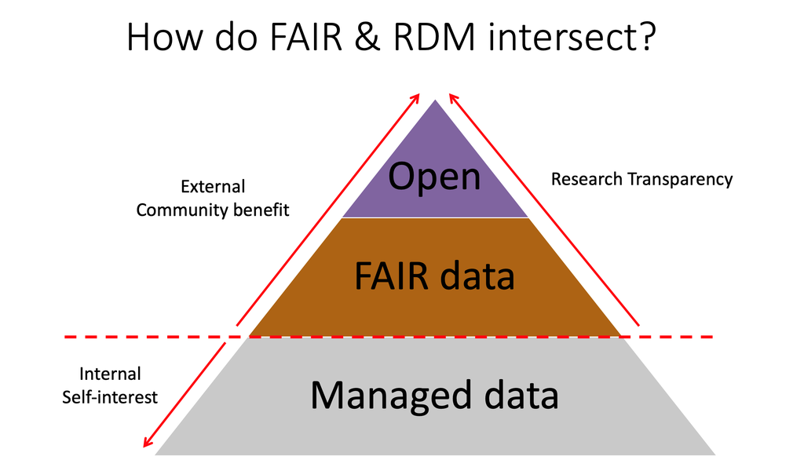

(Jones 2018)

## Resources To Start With

- Practical Reproducibility
  - Transparent and Reproducible Social Science Research (Christensen 2019)
  - Inspiration for a multi-part course on Reproducibility: Reproducible Research Techniques for Synthesis: (National Center for Ecological Analysis and Synthesis, n.d.)
- Organize for Transparent and Reproducible Research
  - Reproducible Science Curriculum: Data & Project Organization (Data Carpentry, n.d.)
  - How to Name Files (Bryan 2015)
- Version Control with Git and GitHub
  - Git Command Line Basics [https://www.youtube.com/watch?v=HVsySz-h9r4]
- Sharing Your Data for Transparent and Reproducible Research
  - Data Management vs FAIR (Higman, Bangert, and Jones 2019)
  - Best Practices (Briney, Coates, and Goben 2020)
- Reproducible Analysis and Documentation in RStudio and R Markdown
  - Reproducible Research With R and RStudio (Gandrud 2020)

## Feedback and Assessment

- Track attendance
- Post workshop follow up

## Looking Forward

Some ideas:

- Do specific outreach to departments on this kind of training
- Find a seminar series that this could fit into
- Find “reproducibility champions” who want their grad student to learn these concepts

## More Resources

- Our Workshop materials are available at OSF: https://osf.io/ws3u2
  - There are considerably more references to learn more about each individual topic in the workshop slides
- Research Data Management Services Zotero group library:

  https://www.zotero.org/groups/361046/research_data_management_services/library

## References

Briney, Kristin, Heather Coates, and Abigail Goben. 2020. “Foundational Practices of Research Data Management.” *Research Ideas and Outcomes* 6 (July): e56508. https://doi.org/10.3897/rio.6.e56508.

Bryan, Jenny. 2015. “How to Name Files.” *Speaker Deck*. https://speakerdeck.com/jennybc/how-to-name-files.

Christensen. 2019. *Transparent and Reproducible Social Science Research*. First edition. Oakland, California: University of California Press.

Data Carpentry. n.d. “Reproducible Science Curriculum: Data & Project Organization.” https://reproducible-science-curriculum.github.io/organization-RR-Jupyter/.

Gandrud, Christopher. 2020. *Reproducible Research with R and RStudio*. 3rd edition. Boca Raton, FL: Chapman and Hall/CRC.

Higman, Rosie, Daniel Bangert, and Sarah Jones. 2019. “Three Camps, One Destination: The Intersections of Research Data Management, FAIR and Open.” *Insights* 32 (1): 18. https://doi.org/10.1629/uksg.468.

Jones, Sarah. 2018. “Open Data, FAIR Data and RDM: The Ugly Duckling.” Berlin. https://doi.org/10.5281/zenodo.1196631.

National Center for Ecological Analysis and Synthesis. n.d. “Reproducible Research Techniques for Synthesis.” *National Center for Ecological Analysis and Synthesis*. https://www.nceas.ucsb.edu/learning-hub/short-course.